# Assignment 2

Christmas is right around the corner, and just like every good child, I'm certain that you, dear Reader, asked for a fresh machine learning assignment in your stockings. No? But Santa's list never lies! Hang up the mistletoe and get cozy, because on the following pages you can read a about the intricacies of a few regression methods and some very hip outlier detection in images.

```python
import numpy as np
import pandas as pd
from sklearn.datasets import fetch_california_housing
from sklearn.model_selection import train_test_split
from sklearn.preprocessing import StandardScaler
from sklearn.kernel_ridge import KernelRidge
from sklearn.linear_model import BayesianRidge
from sklearn.gaussian_process import GaussianProcessRegressor
from sklearn.metrics import mean_squared_error, r2_score
import matplotlib.pyplot as plt

# Load the California Housing Prices dataset
data = fetch_california_housing()
X = pd.DataFrame(data.data, columns=data.feature_names)
y = data.target

# Split the data into training and testing sets
X_train, X_test, y_train, y_test = train_test_split(X, y, test_size=0.2, random_state=42)

# Standardize the data
scaler = StandardScaler()
X_train_scaled = scaler.fit_transform(X_train)
X_test_scaled = scaler.transform(X_test)
```

### 1. Data Exploration and Preprocessing

Since we are using the same dataset as before (California Housing Prices), I would only like to pinpoint some of the major findings from the previous assignments data exploration part:

- There are 20,640 observations
- All variables are numeric
- The dataset contains quite a few outliers when we examine the median income, the population, the average occupancy or our target variable, the median house value
- A households income is highly correlated with the neighbourhood's median house value in which they are located, the number of rooms and bedrooms correlate highly with each other, and the longitude and latitude has a high correlation as well, which comes from the shape of the state
- I standardized the data

#### 2. Kernel Ridge Regression (KRR)

For our first regression we will use a Kernel Ridge regression. The algorithm combines Ridge Regression with the Kernel regression, meaning it can capture non-linear relationships between the target and the feature variables, but also penalizes the model for using too many inputs. The hyperparameter that we can play around with is alpha, responsible for controlling the regularization strength, similar to how it works in Ridge Regression. A smaller value of alpha allows the model to fit the training data more closely, which could lead to overfitting, while a higher could result in underfitting. I tested different alphas for the best result based on their R2 value and ended up with an alpha of 0.01. Since this looked suspicious, I used another method using sklearn's model selection to make sure that I am not just overfitting the data, but it yielded the same results, thus I accepted it.

```python
alpha_values = [0.01, 0.1, 0.2,0.3,0.4,0.5, 1, 10]

mse_score = []
r2_scores = []


# Iterate over values
for alpha in alpha_values:
        krr_model = KernelRidge(kernel='rbf', alpha=alpha)

        krr_model.fit(X_train_scaled, y_train)
        y_pred_krr = krr_model.predict(X_test_scaled)
        mse_krr = mean_squared_error(y_test, y_pred_krr)
        r2_krr = r2_score(y_test, y_pred_krr)
        mse_score.append(mse_krr)
        r2_scores.append(r2_krr)


best_alpha_index = np.argmax(r2_scores)
best_alpha = alpha_values[best_alpha_index]
print("Best Alpha:", best_alpha)
```

```
Best Alpha: 0.01
```

```python
alpha_values = [0.01, 0.1, 0.2,0.3,0.4,0.5, 1, 10]
cross_val_scores = []


for alpha in alpha_values:

    krr_model = KernelRidge(kernel='rbf', alpha=alpha)

    scores = cross_val_score(krr_model, X_train_scaled, y_train, cv=5, scoring='neg_mean_squared_error')

    cross_val_scores.append(np.mean(scores))

best_alpha_index = np.argmax(cross_val_scores)
best_alpha = alpha_values[best_alpha_index]

print("Best Alpha:", best_alpha)
```

```
Best Alpha: 0.01
```

I only addressed alpha so far, but it is also important to find the best kernel for the problem. I modified the code a bit to iterate through three kernels and find the best one for the job. As it turns out, it is the previously used Radial Basis Function, so our model does not need any changes.

```python
alpha_values = [0.01, 0.1, 0.2,0.3,0.4,0.5, 1, 10]

mse_score = []
r2_scores = []
results = []
kernels = ['linear', 'rbf', 'poly']

# Iterate over values
for kernel in kernels:
    for alpha in alpha_values:
        krr_model = KernelRidge(kernel=kernel, alpha=alpha)

        krr_model.fit(X_train_scaled, y_train)
        y_pred_krr = krr_model.predict(X_test_scaled)
        mse_krr = mean_squared_error(y_test, y_pred_krr)
        r2_krr = r2_score(y_test, y_pred_krr)

        results.append({'Kernel': kernel, 'Alpha': alpha, 'MSE': mse_krr, 'R2 Score': r2_krr})

results_df = pd.DataFrame(results)
best_r2_row = results_df.loc[results_df['R2 Score'].idxmax()]
best_mse_row = results_df.loc[results_df['MSE'].idxmin()]

print("Best Alpha for R2 Score:", best_r2_row['Alpha'])
print("Best Kernel for R2 Score:", best_r2_row['Kernel'])
print("Best Alpha for MSE:", best_mse_row['Alpha'])
print("Best Kernel for MSE:", best_mse_row['Kernel'])
```

```
Best Alpha for R2 Score: 0.01
Best Kernel for R2 Score: rbf
Best Alpha for MSE: 0.01
Best Kernel for MSE: rbf
```

The results are rather good, with a 0.76 R2 score, but still lower than the performance of previous assignment's random forest and gradient boosting.

```python
krr_model_alpha05 = KernelRidge(kernel='rbf', alpha=0.01)
krr_model_alpha05.fit(X_train_scaled, y_train)
y_pred_krr = krr_model_alpha05.predict(X_test_scaled)

mse_krr = mean_squared_error(y_test, y_pred_krr)
r2_krr = r2_score(y_test, y_pred_krr)
rmse_krr = np.sqrt(mse_krr)

ridge = pd.DataFrame({
    'MSE': [mse_krr],
    'RMSE': [rmse_krr],
    'R2 Score': [r2_krr]
})

print(ridge)
```

```
        MSE     RMSE  R2 Score
0  0.312235  0.55878  0.761727
```

#### 3. Bayesian Linear Regression

Next up, we have Bayesian linear regression. It uses a probabilistic approach to model the relationship between the features and the target, giving us a probability distribution over possible values given parameters. The model doesn't seem to fit our data very well: it has a R2 score of only 0.58, lower than KRR or other previously used methods.

```python
# Bayesian Linear Regression
bayesian_model = BayesianRidge()
bayesian_model.fit(X_train_scaled, y_train)
y_pred_bayesian = bayesian_model.predict(X_test_scaled)

mse_bayesian_ridge = mean_squared_error(y_test, y_pred_bayesian)
rmse_bayesian_ridge = np.sqrt(mse_bayesian_ridge)
r2_bayesian_ridge = r2_score(y_test, y_pred_bayesian)


bayesian_ridge_results = pd.DataFrame({
    'MSE': [mse_bayesian_ridge],
    'RMSE': [rmse_bayesian_ridge],
    'R2 Score': [r2_bayesian_ridge]
})

print(bayesian_ridge_results)
```

```
        MSE      RMSE  R2 Score
0  0.555831  0.745541  0.575834
```

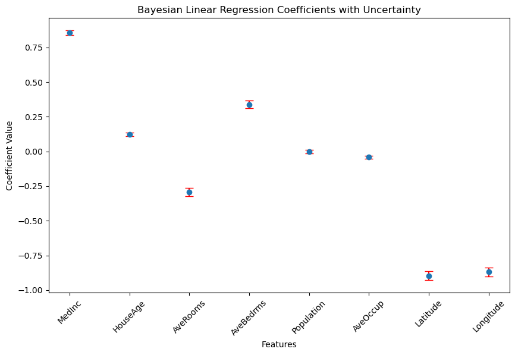

```python
# Extract the standard deviation of the coefficients
std_dev_coef = np.sqrt(np.diag(bayesian_model.sigma_))

# Plotting
plt.figure(figsize=(10, 6))
plt.errorbar(range(len(bayesian_model.coef_)), bayesian_model.coef_,
             yerr=1.96*std_dev_coef, #  to approximate the 95% confidence interval for the coefficients.  95% of the values lie within approximately 1.96 standard deviations from the mean.(coefficient - 1.96 * std_dev)
             fmt='o',
             ecolor='r',
             capsize=5)
plt.xticks(range(len(bayesian_model.coef_)), data.feature_names, rotation=45)
plt.xlabel('Features')
plt.ylabel('Coefficient Value')
plt.title('Bayesian Linear Regression Coefficients with Uncertainty')
plt.show()
```

#### 4. Gaussian Process Regression

Our next model, the Gaussian Process Regression is a non-parametric Bayesian regression technique, meaning it will also give us a probability distribution about the estimated coefficients. It is also based on a prior belief which is updated with information gained from the data.

```python
from sklearn.gaussian_process.kernels import Matern

kernel = Matern(length_scale=1.0, length_scale_bounds=(1e-1, 1.0), nu=1.5)
gpr_model = GaussianProcessRegressor(kernel=kernel, random_state=42)


gpr_model.fit(X_train_scaled, y_train)
y_pred_gpr, std_dev_gpr = gpr_model.predict(X_test_scaled, return_std=True)
```

The results of the model are considerably better then the aforementioned simple bayesian linear regression, but still pale in comparison to our other models.

```python
mse_gpr = mean_squared_error(y_test, y_pred_gpr)
r2_gpr = r2_score(y_test, y_pred_gpr)
rmse_gpr = np.sqrt(mse_bayesian_ridge)


gpr_results = pd.DataFrame({
    'MSE': [mse_gpr],
    'RMSE': [rmse_gpr],
    'R2 Score': [r2_gpr]
})

print(gpr_results)
```

```
        MSE      RMSE  R2 Score
0  0.444265  0.745541  0.660972
```

#### 5. Comparative Analysis

Kernel ridge regression seems to be the best possibility from this assignment's models, since it has the highest R2 and the lowest MSE. Computationally Bayesian was the fastest to run, while Gaussian was the slowest, but as it is the case with all three algorithms the use of sub-sampling can increase their computational efficiency.

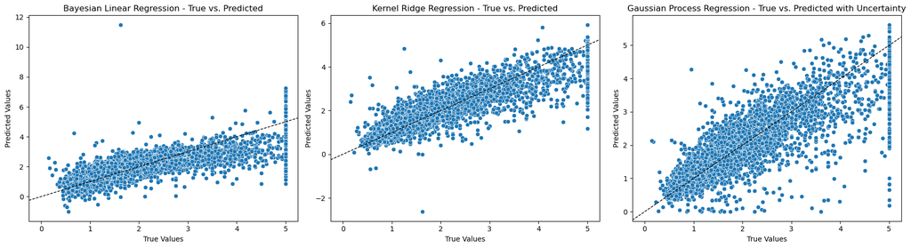

```python
plt.figure(figsize=(18, 5))

# Bayesian Linear Regression
plt.subplot(1, 3, 1)
sns.scatterplot(x=y_test, y=y_pred_bayesian)
plt.title('Bayesian Linear Regression - True vs. Predicted')
plt.xlabel('True Values')
plt.ylabel('Predicted Values')
plt.axline(xy1=(0, 0), slope=1, color='black', linestyle='--', linewidth=1)

# KRR
plt.subplot(1, 3, 2)
sns.scatterplot(x=y_test, y=y_pred_krr)
plt.title('Kernel Ridge Regression - True vs. Predicted')
plt.xlabel('True Values')
plt.ylabel('Predicted Values')
plt.axline(xy1=(0, 0), slope=1, color='black', linestyle='--', linewidth=1)

#Gaussian Process Regression
plt.subplot(1, 3, 3)
sns.scatterplot(x=y_test, y=y_pred_gpr)
plt.title('Gaussian Process Regression - True vs. Predicted with Uncertainty')
plt.xlabel('True Values')
plt.ylabel('Predicted Values')
plt.axline(xy1=(0, 0), slope=1, color='black', linestyle='--', linewidth=1)


plt.tight_layout()
plt.show()
```

```python
# Evaluate the models
mse_krr = mean_squared_error(y_test, y_pred_krr)
mse_bayesian = mean_squared_error(y_test, y_pred_bayesian)
mse_gpr = mean_squared_error(y_test, y_pred_gpr)

r2_krr = r2_score(y_test, y_pred_krr)
r2_bayesian = r2_score(y_test, y_pred_bayesian)
r2_gpr = r2_score(y_test, y_pred_gpr)

# Display results
results = pd.DataFrame({
    'Model': ['Kernel Ridge Regression', 'Bayesian Linear Regression', 'Gaussian Process Regression'],
    'MSE': [mse_krr, mse_bayesian, mse_gpr],
    'R2 Score': [r2_krr, r2_bayesian, r2_gpr]
})

results
```

|  | Model | MSE | R2 Score |
| --- | --- | --- | --- |
| 0 | Kernel Ridge Regression | 0.312235 | 0.761727 |
| 1 | Bayesian Linear Regression | 0.555831 | 0.575834 |
| 2 | Gaussian Process Regression | 0.444265 | 0.660972 |

Bayesian processes are easy to interpret, since most people with at least a minimal background in statistics can understand the meaning behind coefficients being described by probability, how confident we are about the actual value of a coefficient and we can still compare the importance of features. The kernel function maps inputs into a higher-dimensional space,and since we are using and RBF it makes weights harder to interpret due to the non-linear relationship. If we can compromise on interpretability, since we only want to get good predictions we should go with KRR, while if we rather be able to see each input's effect on the target we could use the Gaussian process.

```python
import numpy as np
import matplotlib.pyplot as plt
from scipy.spatial.distance import cdist
import numpy as np
import matplotlib.pyplot as plt
from sklearn.datasets import make_classification
from sklearn.decomposition import PCA
from tensorflow.keras.models import Sequential
from tensorflow.keras.layers import Dense
import tensorflow as tf
```

[output not shown]

# 2. Outlier detection

In this second part of the assignment we will delve into outlier detection. Our dataset is a from a fashion collection, to which we've manually added some outliers, just to have something to look for. If we take a look at the raw data we will only see a lot of numbers, but if we out them into an image reshape they come alive.

```python
data = np.load('fmnist_710.npz')
images, labels  = data['x'] , data['y']
train_images = images.astype('float32') / 255
X = train_images.reshape((train_images.shape[0], -1))
X.shape
```

```
(1210, 784)
```

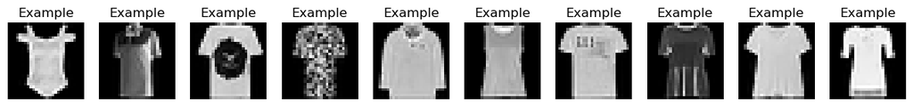

```python
def display_images(images, labels, num_images=10):
    plt.figure(figsize=(15, 2))
    for i in range(num_images):
        plt.subplot(1, num_images, i + 1)
        plt.imshow(images[i], cmap='gray')
        plt.title(f"Example")
        plt.axis('off')
    plt.show()
display_images(images, labels)
```

We can see that they are different kinds of cloths. Our goal is to find the not so fashionable ones, so to speak. Every piece of cloth has a label, a number from 0 to 9. If we visualize the distribution of the labels we can see that there is the same amount of observations in every class except for class 6.

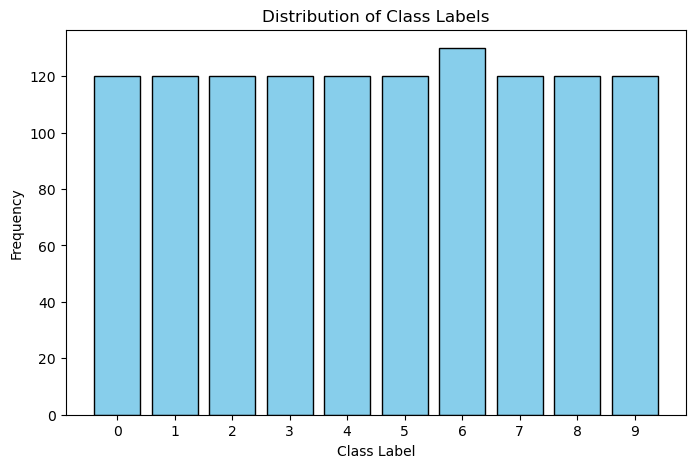

```python
plt.figure(figsize=(8, 5))
plt.hist(labels, bins=np.arange(11) - 0.5, rwidth=0.8, color='skyblue', edgecolor='black')
plt.xticks(np.arange(10))
plt.xlabel('Class Label')
plt.ylabel('Frequency')
plt.title('Distribution of Class Labels')
plt.show()
```

Furthermore we can look at the pixel distribution of images, to see how frequently do we observe a certain amount of value in a cell (so the values in individual pixels of the picture). We can see that we usually observe a small amount of pixels, suggesting that most of the pictures contain black regions. If we filter out the small pixel values, the distribution is rather left-skewed, meaning that those pixels containing information are rather bright/colorful.

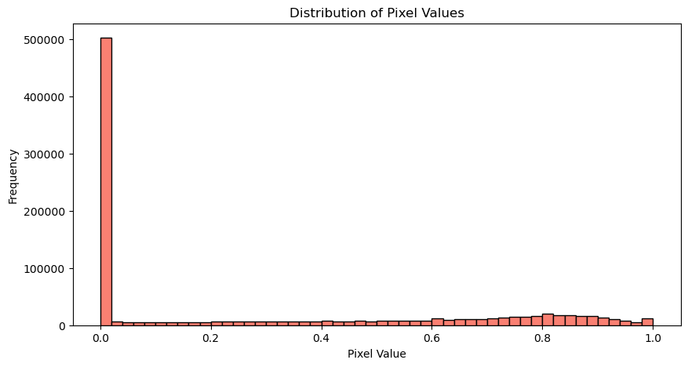

```python
plt.figure(figsize=(10, 5))
plt.hist(X.flatten(), bins=50, color='salmon', edgecolor='black')
plt.xlabel('Pixel Value')
plt.ylabel('Frequency')
plt.title('Distribution of Pixel Values')
plt.show()
```

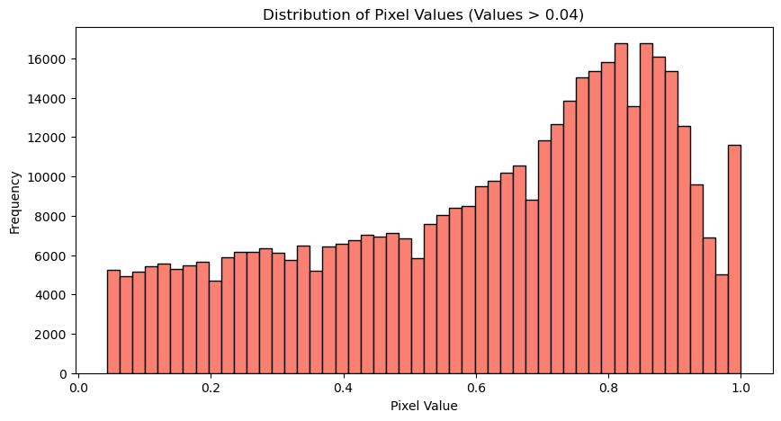

```python
filtered_pixel_values = X[X > 0.04]
plt.figure(figsize=(10, 5))
plt.hist(filtered_pixel_values.flatten(), bins=50, color='salmon', edgecolor='black')
plt.xlabel('Pixel Value')
plt.ylabel('Frequency')
plt.title('Distribution of Pixel Values (Values > 0.04)')
plt.show()
```